# Dimension Reduction

by Edneide Ramalho

02/08/2021

In this lesson we’ll discuss principal component analysis (PCA) and singular value decomposition (SVD), two important and related techniques of dimension reduction. This last entails processes which finding subsets of variables in datasets that contain their essences. PCA and SVD are used in both the exploratory phase and the more formal modelling stage of analysis. We’ll focus on the exploratory phase and briefly touch on some of the underlying theory.

```r
library(readr)
dataMatrix <- read_csv("dataMatrix.csv")
head(dataMatrix)
```

```
## # A tibble: 6 x 11
##      X1     V1     V2     V3     V4     V5     V6     V7     V8     V9     V10
##   <dbl>  <dbl>  <dbl>  <dbl>  <dbl>  <dbl>  <dbl>  <dbl>  <dbl>  <dbl>   <dbl>
## 1     1  0.586  1.13   0.645  1.54  -0.488 -1.44  -0.700 -1.51   0.380 -0.376
## 2     2  0.709 -2.38   1.04   1.32   0.303 -0.629 -0.567  0.164  0.605 -1.81
## 3     3 -0.109 -1.06  -0.304  0.322 -0.242  0.244 -0.261 -0.871  1.02   0.289
## 4     4 -0.453  0.937  2.48   1.53  -0.482  1.06  -1.06   1.59   0.475 -0.190
## 5     5  0.606  0.854  0.971 -0.421 -0.992  0.831 -0.106  0.647 -2.19   0.0179
## 6     6 -1.82   1.46   1.87  -1.16  -0.281  0.105  0.771  0.357  0.933  0.650
```

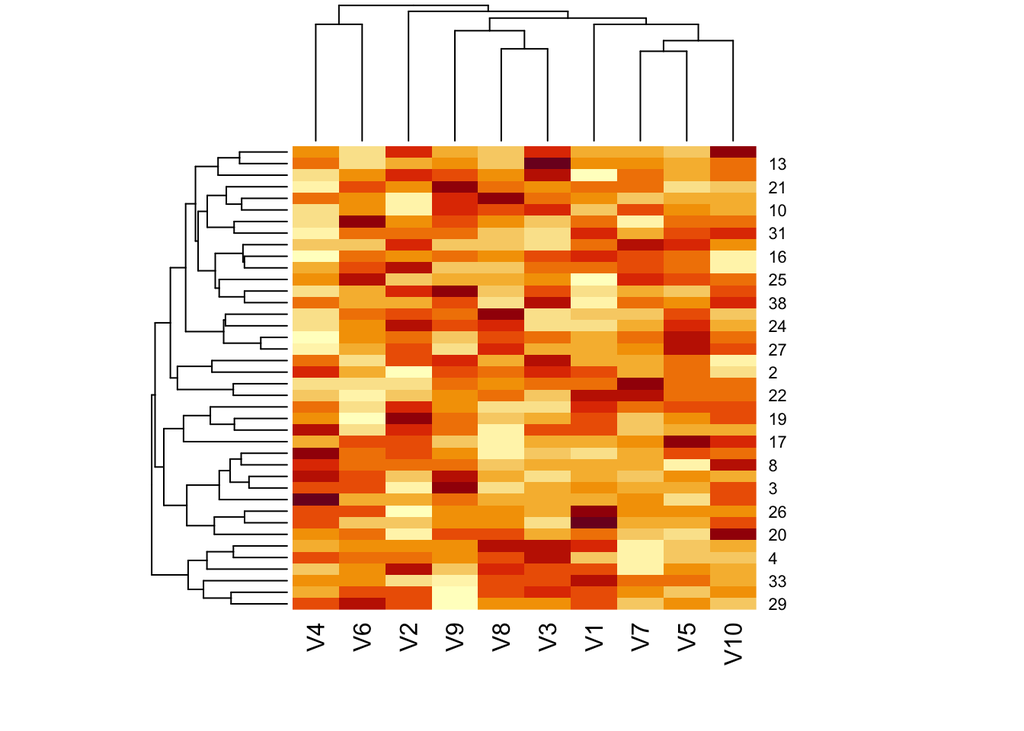

```r
dataMatrix <- dataMatrix[, -1]
tempMatrix <- as.matrix(dataMatrix)
heatmap(tempMatrix)
```

We can see that even with the clustering that heatmap provides, permuting the rows (observations) and columns (variables) independently, the data still looks random.

Let’s add a pattern to the data. We’ve put some R code in the file addPatt.R for you. Run the command myedit with the single argument “addPatt.R” (make sure to use the quotation marks) to see the code. You might have to click your cursor in the console after you do this to keep from accidentally changing the file.

So in rows affected by the coin flip, the 5 left columns will still have a mean | of 0 but the right 5 columns will have a mean closer to 3.

```r
addPatt <- function(){
  set.seed(678910)
for(i in 1:40){
  # flip a coin
  coinFlip <- rbinom(1,size=1,prob=0.5)
  # if coin is heads add a common pattern to that row
  if(coinFlip){
    dataMatrix[i,] <- dataMatrix[i,] + rep(c(0,3),each=5)
  }
}
  return(dataMatrix)
}
```

```r
new_dataMatrix <- addPatt()
```

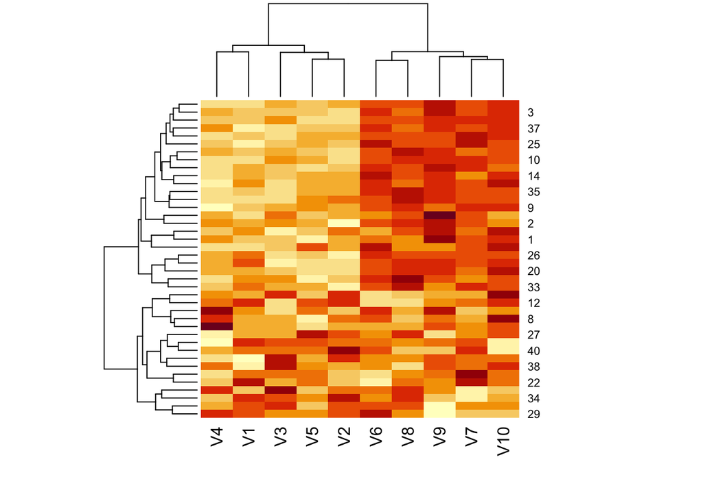

```r
heatmap(as.matrix(new_dataMatrix))
```

| Again we see the pattern in the columns of the matrix. As shown in the | dendrogram at the top of the display, these split into 2 clusters, the lower | numbered columns (1 through 5) and the higher numbered ones (6 through 10). | Recall from the code in addPatt.R that for rows selected by the coinflip the | last 5 columns had 3 added to them. The rows still look random.